# KOLAY RESTAURANT DATA & PROFITABILITY / POPULARITY ANALYSIS

This report contains graph and table about the Kolay Restaurant.

The interactive graph are created to depict the popularity and profit attributes of the items relative to others.

As we do not have a real cost data, we created a dummy cost data based on reasonable assumptions. Profit was simply calculated by multiplying the difference between net revenue and costs with amount of items sold.

Even now the graph shows us meaningful information such as lahmacun, ayran and tulum peyniri being very popular and that they sell a lot more than almost every other item in the menu.

The dataset that sent to us are now cleaned and changed in terms of new columns. The dataset also changed to interactive datatable to be able to search, sort, and filter the data.

Interactive graph that represents the real profit could be made immediately after real cost data arrives.

TOP 10 SOLD PRODUCTS.

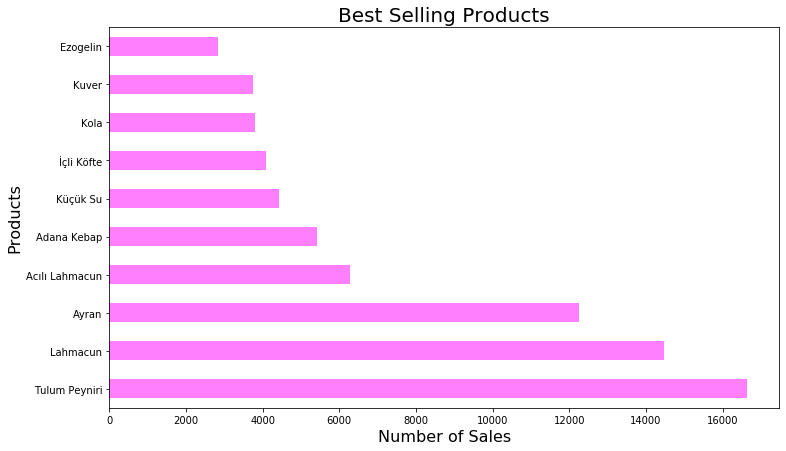

WORST 10 SOLD PRODUCTS.

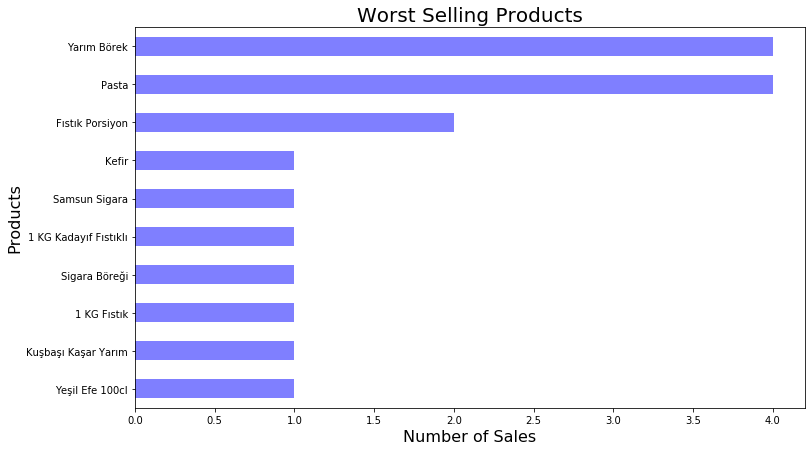

Explanation of groups and strategies that can be followed.

Stars are highly popular and more profitable which means that they are contributing heavily to the margin and popularity of the restaurant than others. These dishes are your specialties in the market so you don’t have to worry about these but you must go for maintaining quality and quantity standards of the dishes.

Puzzles are highly profitable but less popular. It means that these items are can contribute heavily to the profits if their popularity can be increased. So some popularity increasing techniques will do and this can be done by:

- Place them at the most visible part of menu, to capture the guest attention. This will increase their sale and as they are already highly profitable which means in the end their contribution to the restaurants profits will be high.
- Another strategy can be giving add-ons. It will increase the popularity.
- Price can be decreased to increase popularity. This can be very good technique. But it is very important to note that by decreasing prices we will be decreasing profits from them. So proper pricing strategy should be coined.

Horses are highly popular but less profitable. It means we have to increase the profit margins from these. For this management we can:

- Go for appropriate profit increasing techniques like increase price. People will not mind paying more as they love these items but it should be noted that it doesn’t mean an unreasonable hike in prices. A thorough study of the market will reveal the appropriate price and pricing strategy for these.
- Reducing portion size can be another useful strategy to increase margins as it will decrease food cost.
- Place them away from focal point in the menu. This will not affect their sale as they are already very popular items of this menu, but it will help in increasing sale of other items.

Dogs are neither profitable nor popular. The best possible strategy for these items is to remove these from the menu and introduce some new items.

There are 2 missing product data that we later learned have been deleted from menu.

Let's see our graph with quadrant and groups...

As we see in the graph there is two lines which determine the graph's quadrants. These lines are determined by Kasavana Smith calculations.

For x-axis line, we divide total sum of profit by the number of products sold.

For y-axis line, we divide total number of products sold by the number of products sold. After that we multiply that number with 0.7 because of Kasavana Smith calculation.

When real cost data arrive, we can rearrange graph's quadrant lines by these calculations.

# You can drag the mouse and use the buttons on the side to zoom in the graph.

[interactive chart not shown]